# Lab 7 - BINF 6310

Erin Tsai

5/13/2021

### Problem 1:

##### RNA seq dataset of E. Coli genes from mice here: http://afodor.github.io/classes/stats2015/longitdunalRNASeqData.zip

##### Read and normalize the counts table.

```r
myT = read.table("longitdunalRNASeqData/nc101_scaff_dataCounts.txt", sep = "\t", header = TRUE, row.names = 1)

myT = myT[apply(myT, 1, median)> 5,]

myTNorm = myT
for(i in 1:ncol(myT)){
  colSum = sum(myT[,i])
  myTNorm[,i] = myTNorm[,i]/colSum
}
```

##### 1A) For each row in the spreadsheet, perform a one-way ANOVA with categories “day2”, “week 12”, and “week 18”. Plot out the histogram of all p-values.

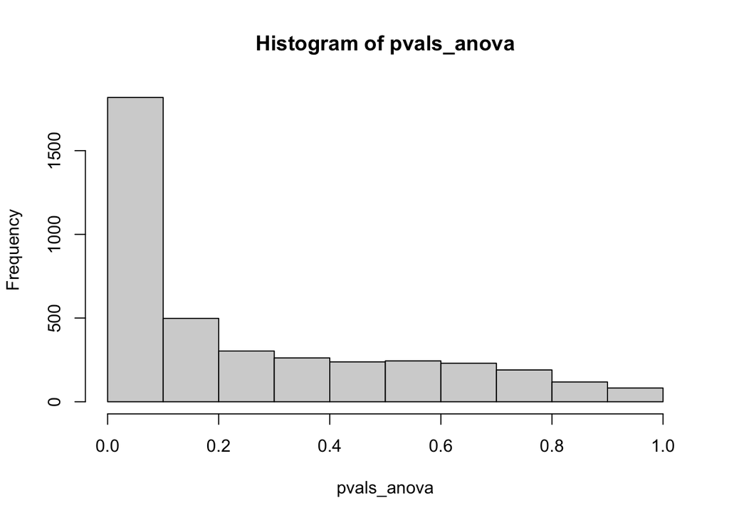

```r
time_points = factor(c(rep('Day2', 3), rep('Week12',3), rep('Week18', 5)))
pvals_anova = vector(mode = "numeric", length = nrow(myTNorm))

for(i in 1:nrow(myTNorm)){

  row = as.numeric(myTNorm[i,])

  myLm = lm(row ~ time_points, x = TRUE)

  pvals_anova[i] = anova(myLm)$"Pr(>F"[1]
}

hist(pvals_anova)
```

```r
fdr_pvals = sum(p.adjust(pvals_anova, 'BH') < 0.05)
```

How many genes are significant at a BH FDR-corrected 0.05 threshold.

- **612** genes are significant at a BH FDR-corrected 0.05 threshold.

##### 1B) Next make an ANOVA as a linear regression as a function of time (so 2 days, 86 days, and 128 days). Plot out the histogram of all p-values.

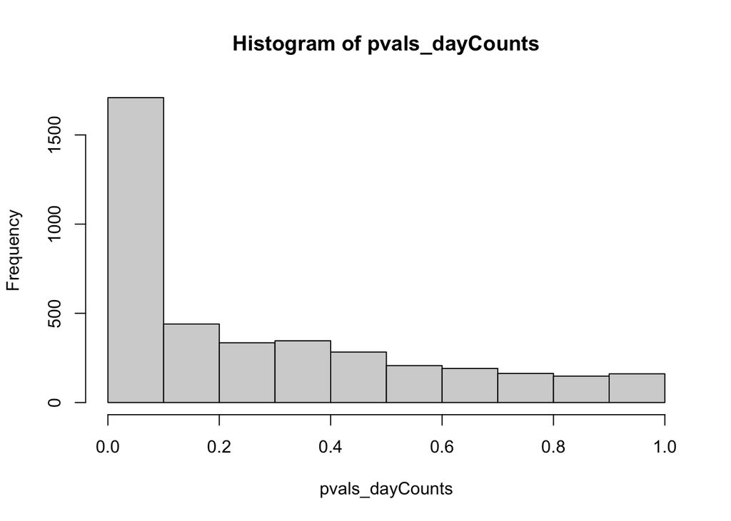

```r
day_points = c(rep(2, 3), rep(86,3), rep(128, 5))
pvals_dayCounts = vector(mode = "numeric", length = nrow(myTNorm))

for(i in 1:nrow(myTNorm)){

  row1 = as.numeric(myTNorm[i,])

  myLm1 = lm(row1 ~ day_points, x = TRUE)

  pvals_dayCounts[i] = anova(myLm1)$"Pr(>F"[1]
}

hist(pvals_dayCounts)
```

```r
fdr_pvals_days = sum(p.adjust(pvals_dayCounts, 'BH') < 0.05)
```

How many genes are significant at a BH FDR-corrected 0.05 threshold.

- **448** genes are significant at a BH FDR-corrected 0.05 threshold.

##### 1C) Finally, for each row in the spreadsheet perform an ANVOA comparing the three-parameter model from (1A) and the two parameter model from (1B). Plot out the histogram of all p-values.

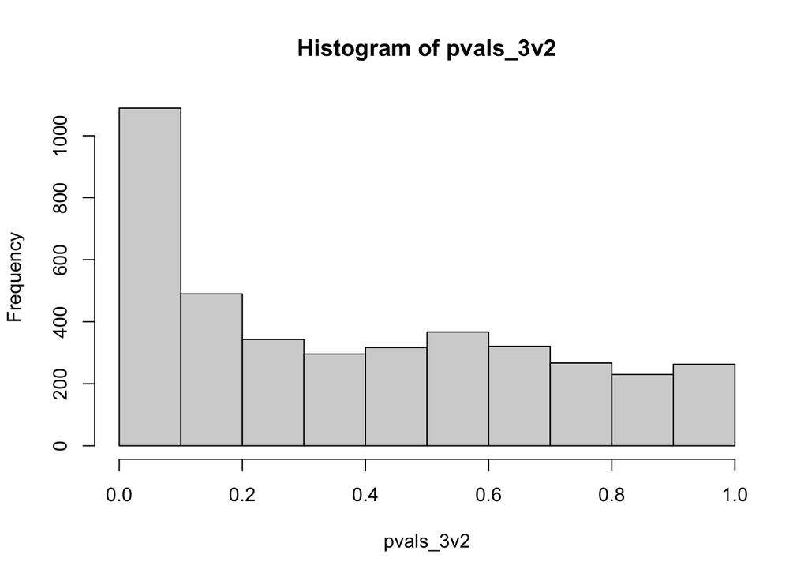

```r
pvals_3v2 = vector(mode = "numeric", length = nrow(myTNorm))

for(i in 1:nrow(myTNorm)){
  row = as.numeric(myTNorm[i,])
  myLm = lm(row ~ time_points, x = TRUE)
  row1 = as.numeric(myTNorm[i,])
  myLm1 = lm(row1 ~ day_points, x = TRUE)

  a_residuals = sum(residuals(myLm)^2)
  b_residuals = sum(residuals(myLm1)^2)

  f = ((b_residuals - a_residuals)/1)/(a_residuals/8)

  pvals_3v2[i] = pf(f, 1, 8, lower.tail = FALSE)
}

hist(pvals_3v2)
```

```r
fdr_3v2 = sum(p.adjust(pvals_3v2, 'BH') < 0.05)
```

For how many genes is there a significant difference between these two models at a BH FDR-corrected threshold.

- **51** gene(s) show a significant difference between these two models at a BH FDR-corrected threshold.

##### 1D) Make three graphs showing the relative abundance of the most significant gene under each of the three ANOVA models. For (A) and (C), the x-axis will the category (day 3, week 12 and week 18) and the y-axis will be the relative abundance. Be sure to properly label and title all graphs and axes. For (B) the x-axis will be time (in days) and the y-axis will be the relative abundance. For the graph of the top hit from (B), include the regression line for the plot from (B).

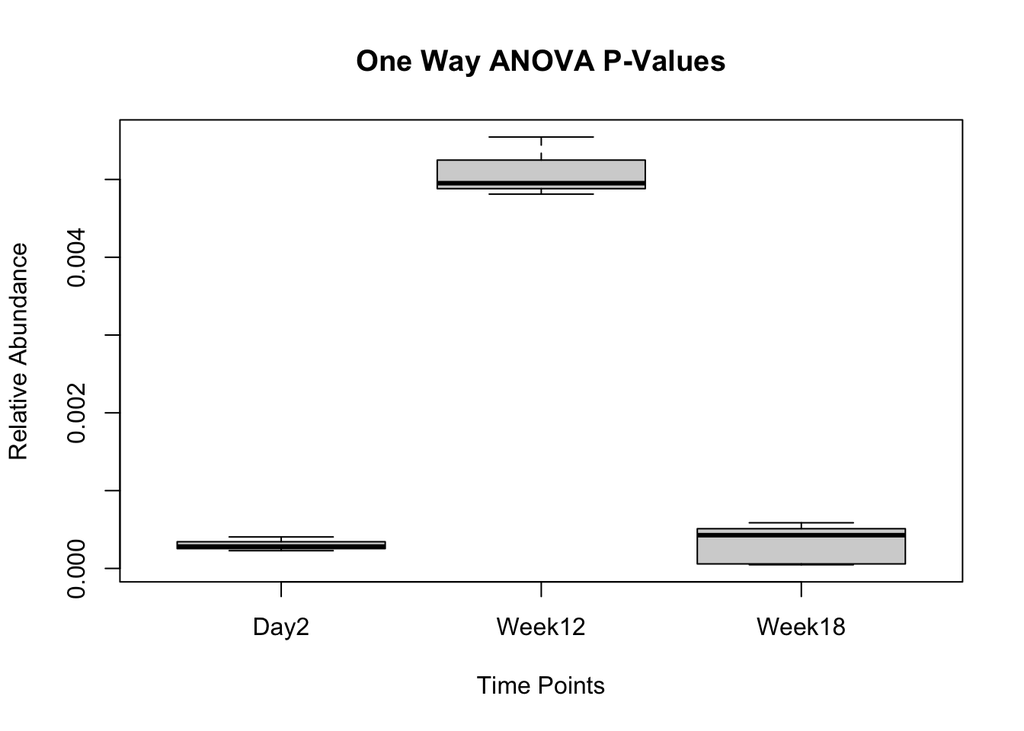

```r
index = 0
for(i in 1:nrow(myTNorm)){
  index[i] = i
}

myFrame = data.frame(index, pvals_anova, pvals_dayCounts, pvals_3v2)

myFrame1 = myFrame[order(myFrame$pvals_anova), ]
myFrame2 = myFrame[order(myFrame$pvals_dayCounts), ]
myFrame3 = myFrame[order(myFrame$pvals_3v2), ]

boxplot(as.numeric(myTNorm[myFrame1$index[1], ]) ~ time_points, xlab = "Time Points", ylab = "Relative Abundance", main = "One Way ANOVA P-Values")
```

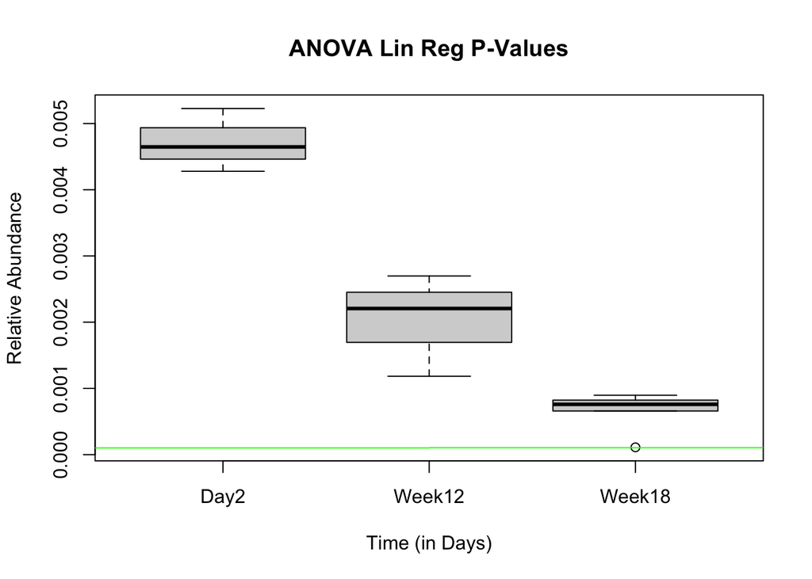

```r
boxplot(as.numeric(myTNorm[myFrame2$index[1], ]) ~ time_points, xlab = "Time (in Days)", ylab = "Relative Abundance", main = "ANOVA Lin Reg P-Values")
abline(myLm1, col='green')
```

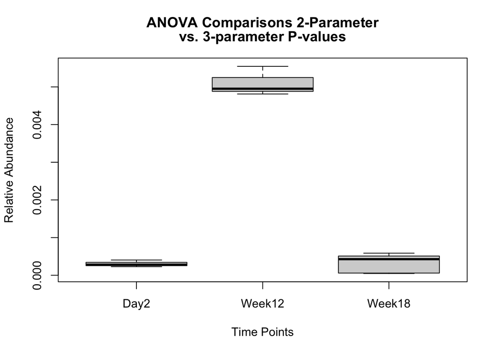

```r
boxplot(as.numeric(myTNorm[myFrame3$index[1], ]) ~ time_points, xlab = "Time Points", ylab = "Relative Abundance", main = c(("ANOVA Comparisons 2-Parameter"), ("vs. 3-parameter P-values")))
```